# Traits sampling summary in Mbalmayo and Bouamir

Gilles Dauby

2025-10-20

```r
# to install the package 'plotsdatabase'
# make sure you are running recent R version

devtools::install_github("gdauby/bdd_plots_central_africa")
## if the installation above failed, it may be because your timeout is too low
## you can increase the timeout by using the following code
options(timeout = 1000)

library(tidyverse)
library(plotsdatabase) ## R package for exploring the database
library(sf)
library(gt)
```

Vérifier que la version du package est bien la [dernière en ligne](https://github.com/gdauby/bdd_plots_central_africa/blob/master/DESCRIPTION).

```r
packageVersion("plotsdatabase")
```

```
## [1] '1.2'
```

# Extract data from the database

Concerning observatories, taxonomic and traits data are stored and managed in this database. Phenological characterization and spatial vectors linked to each tree (crown polygons) are managed trough the Shiny apps.

Data are stored in a postrgresql relational database and are available with several ‘query’ functions using an R package and a proper password and login name (ask Gilles).

Data is subject to evolve regularly : new data can be added and taxonomic identification can be updated.

Extract datasets for mbalmayo and bouamir observatories.

```r
tree_data <-
  query_plots(
    locality_name = c("Bouamir", "Mbalmayo", "Loundoungou"),
    method = c("1ha-IRD", "phenological_observatory"),
    extract_individuals = TRUE,
    remove_ids = F
  )

meta_data <-
    query_plots(
    locality_name = c("Bouamir", "Mbalmayo", "Loundoungou"),
    method = c("1ha-IRD", "phenological_observatory"),
    remove_ids = F,
  )
```

Query all features (including traits) linked to an individual of the observatory. A feature can be anything (including traits but not only).

```r
### export all features linked to an individual

all_traits_features <-
  query_individual_features(
    individual_ids = tree_data$id_n,
    format = "long",
    remove_issues = TRUE,
    include_metadata = TRUE)
```

```
## ── Fetching trait measurements ──
```

```
## ℹ Processing 21 chunk(s) for individual features
```

```
## ℹ Removed 2147 measurement(s) with issues
## ℹ Enriching with measurement metadata
## ℹ Found 233623 measurement feature(s)
## ✔ Query completed: 227382 measurement(s)
```

# Explore and rearrange the dataset

Number of trees, plots and observatories

```r
tree_data %>%
  left_join(meta_data %>% select(plot_name, method)) %>%
  group_by(plot_name, method, locality_name) %>%
  count() %>%
  ungroup() %>%
  group_by(method) %>%
  summarise(nbe_plot = n(),
            nbe_individual = sum(n),
            nbe_min_individual = min(n),
            nbe_max_individual = max(n)) %>%
  gt::gt() %>%
   gt::cols_label(
     nbe_individual = "Total number of tree",
     nbe_min_individual = "Minimum number of tree per inventory"
  )
```

| method | nbe_plot | Total number of tree | Minimum number of tree per inventory | nbe_max_individual |
| --- | --- | --- | --- | --- |
| 1ha-IRD | 25 | 12118 | 384 | 623 |
| phenological_observatory | 3 | 8707 | 1428 | 5226 |

The outputs of `query_individual_features` is a list that splits features into character values and numeric values. Character values concern observations done in the field. Numerical values include traits, among others.

```r
numeric_traits <-
  traits_list() %>% filter(valuetype == "numeric")

all_features_num <-
  all_traits_features %>%
  as_tibble() %>%
  filter(id_trait %in% numeric_traits$id_trait)

# print(all_traits_features)

### count number of values for all numerical features

list_features_num <-
  all_features_num %>%
  group_by(trait, id_trait) %>%
  count()


others_traits <-
  traits_list() %>% filter(valuetype != "numeric")

### all character features
all_features_char <-
  all_traits_features %>%
  as_tibble() %>%
  filter(id_trait %in% others_traits$id_trait)
```

```r
list_features_num %>%
  ungroup() %>%
  arrange(desc(n)) %>%
  rename('number of values' = n) %>%
  gt::gt()
```

| trait | id_trait | number of values |
| --- | --- | --- |
| stem_diameter | 1 | 25752 |
| height_of_stem_diameter | 2 | 25424 |
| position_y_iphone | 93 | 10380 |
| position_x_iphone | 94 | 10379 |
| centroid_ddlat | 66 | 4830 |
| centroid_ddlon | 67 | 4830 |
| crown_area | 68 | 4828 |
| leaf_area | 5 | 4326 |
| mesophyl_thickness | 36 | 3142 |
| SPAD_chlorophyll_measurement | 35 | 3117 |
| lma_lamina | 55 | 2813 |
| lma_whole_leaf | 57 | 2674 |
| whole_leaf_area | 59 | 2673 |
| lma_mesophyll | 53 | 2609 |
| leaf_structure_mass_area | 62 | 2171 |
| position_x | 39 | 1641 |
| position_y | 40 | 1641 |
| tree_height | 3 | 1339 |
| leaf_C_percentage | 86 | 570 |
| leaf_N_percentage | 85 | 570 |
| lamina_length | 60 | 556 |
| lamina_width | 61 | 556 |
| twig_specific_gravity | 9 | 555 |
| leaf_delta_carbon_13 | 87 | 550 |
| height_of_first_branch | 11 | 176 |
| total_chlorophyll_content | 76 | 152 |
| water_level_on_trunk | 88 | 115 |
| leaf_Ca_percentage | 91 | 20 |
| leaf_K_percentage | 92 | 20 |
| leaf_P_percentage | 90 | 20 |

# Checklist of traits and features and their definition

```r
all_feat_database <- numeric_traits


all_feat_database <-
  all_feat_database %>%
  filter(grepl("lma_", trait) |
         trait == "twig_specific_gravity"|
         trait == "leaf_area"|
         trait == "SPAD_chlorophyll_measurement"|
         trait == "mesophyl_thickness"|
         trait == "whole_leaf_area"|
         trait == "leaf_structure_mass_area"|
         trait == "total_chlorophyll_content"|
         trait == "leaf_delta_carbon_13"|
         trait == "leaf_N_percentage"|
         trait == "leaf_C_percentage")

list_features_num <-
  list_features_num %>%
  filter(id_trait %in% all_feat_database$id_trait)

features_meta_data <-
  all_feat_database %>%
  filter(id_trait %in% list_features_num$id_trait)

all_features_num <-
  all_features_num %>%
  filter(id_trait %in% list_features_num$id_trait)
```

| trait | id_trait | traitdescription | maxallowedvalue | minallowedvalue | expectedunit | valuetype |
| --- | --- | --- | --- | --- | --- | --- |
| twig_specific_gravity | 9 | Ratio of twig dry mass to twig fresh volume | 100 | 0.0 | g/cm3 | numeric |
| leaf_area | 5 | Leaf area (in case of compound leaves: leaflet, petiole excluded) | 2000 | 0.0 | cm2 | numeric |
| SPAD_chlorophyll_measurement | 35 | SPAD raw measurment | 200 | 0.1 | none | numeric |
| mesophyl_thickness | 36 | Mesophyl thickness | 5 | 0.0 | mm | numeric |
| lma_mesophyll | 53 | Leaf mass per area based on punches collected from the mesophyll avoiding when possible first and second order venation | 1000 | 0.0 | g/m² | numeric |
| leaf_structure_mass_area | 62 | Leaf mass per area only including structural organs (petiole and rachis) | 50000 | 0.0 | g/m² | numeric |
| total_chlorophyll_content | 76 | Total chlorophyll content per leaf mass | 300 | 0.0 | ug/g | numeric |
| lma_whole_leaf | 57 | Leaf mass per area based on whole leaf (include petiole and rachis) | 1000 | 0.0 | g/m² | numeric |
| lma_lamina | 55 | Leaf mass per area based lamina photoynthetic unit (leaflet for compound leaves) | 1000 | 0.0 | g/m² | numeric |
| leaf_delta_carbon_13 | 87 | Stable carbon isotope ratio in leaf material | 0 | -40.0 | per_mill | numeric |
| leaf_N_percentage | 85 | Nitrogen percentage in leaf material | 100 | 0.0 | percentage | numeric |
| leaf_C_percentage | 86 | Carbon percentage in leaf material | 100 | 0.0 | percentage | numeric |
| whole_leaf_area | 59 | Whole leaf area, including petiole and rachis | 7000 | 0.0 | cm² | numeric |

# How traits are collected in the field and metada are associated

Each set of traits measured on a tree in an observatory is associated with a unique number **pheno_tree_nbr** which is incremental.

Thus, each **pheno_tree_nbr** is linked to a tree, to trait measurements, to any observations/remarks on these measurements (for example the *id* of the leaf, because leaf traits are measured for at least 3 leaves), to any axillary measures used for the measurements (for example the area of the leaf for leaf mass per area measurements), to people involved in the measurements and to the date of measurement.

```r
### Extract all measurements with non empty pheno_tree_nbr
all_traits_canopy_trees_cameroon <-
  all_features_num %>%
  filter(!is.na(pheno_tree_nbr)) %>% ### non empty pheno_tree_nbr
  left_join( ### joining and retreiving tree dataset
    tree_data %>% select(id_n, tax_sp_level, tax_gen, plot_name, tag),
    by = c("id_data_individuals" = "id_n")
  ) %>%
  filter(!grepl("lound", plot_name)) %>%
  mutate(colnbr = pheno_tree_nbr) %>%
  mutate(voucher_type = "phenotree")

all_traits_canopy_trees_congo <-
  all_features_num %>%
  filter(!is.na(pheno_tree_nbr)) %>% ### non empty pheno_tree_nbr
  left_join( ### joining and retreiving tree dataset
    tree_data %>% select(id_n, tax_sp_level, tax_gen, plot_name, tag),
    by = c("id_data_individuals" = "id_n")
  ) %>%
  filter(grepl("lound", plot_name)) %>%
  mutate(colnbr = pheno_tree_nbr) %>%
  mutate(voucher_type = "phenocongo")

all_traits_canopy_trees <-
  bind_rows(all_traits_canopy_trees_cameroon,
            all_traits_canopy_trees_congo)

all_traits_plot <-
  all_features_num %>%
  select(-id_specimen) %>%
  left_join(
    ### joining and retreiving tree dataset
    tree_data %>% select(
      id_n,
      tax_sp_level,
      tax_gen,
      plot_name,
      tag,
      id_specimen,
      colnbr
    ),
    by = c("id_data_individuals" = "id_n")
  ) %>%
  filter(!grepl("_observatory", plot_name)) %>% ### filter out all traits measured on trees from phenological observatories
  mutate(voucher_type = "pird")

all_traits <-
  bind_rows(all_traits_canopy_trees, all_traits_plot)

all_traits %>% writexl::write_xlsx("all_traits.xlsx")
```

## See one measurement

```r
all_traits %>%
  slice(2000) %>%
  select(
    id_trait_measures,
    id_trait,
    trait,
    traitvalue,
    colnbr,
    leaf_id,
    leaf_maturity,
    cohort_id,
    colnam,
    whole_leaf_area,
    tag,
    plot_name,
    day,
    month,
    year
  ) %>%
  gt::gt()
```

| id_trait_measures | id_trait | trait | traitvalue | colnbr | leaf_id | leaf_maturity | cohort_id | colnam | whole_leaf_area | tag | plot_name | day | month | year |
| --- | --- | --- | --- | --- | --- | --- | --- | --- | --- | --- | --- | --- | --- | --- |
| 1016203 | 5 | leaf_area | 40.13 | 183 | 6 | mature | 2 | Vincent Pearlstein\|Aicha Mfout Vassah\|Gilles Dauby\|Bidima Emmanuel | NaN | 182 | mbalmayo_pheno_observatory | 7 | 2 | 2024 |

## A glimpse into the raw dataset

| colnbr | voucher_type | tag | tax_sp_level | leaf_id | day | month | year | measurementremarks | measurementmethod | trait | traitvalue | colnam | cohort_id | leaf_maturity |
| --- | --- | --- | --- | --- | --- | --- | --- | --- | --- | --- | --- | --- | --- | --- |
| 46 | phenotree | 833 | Uapaca mole | NaN | NA | 8 | 2024 | 2442-030 | See Silvatech protocols | leaf_delta_carbon_13 | -29.16996 | NA | NaN | NA |
| 46 | phenotree | 833 | Uapaca mole | NaN | NA | 8 | 2024 | 2442-030 | See Silvatech protocols | leaf_C_percentage | 47.75505 | NA | NaN | NA |
| 46 | phenotree | 833 | Uapaca mole | NaN | NA | 8 | 2024 | 2442-030 | See Silvatech protocols | leaf_N_percentage | 1.66030 | NA | NaN | NA |
| 47 | phenotree | 830 | Lophira alata | 1 | NA | 2 | 2023 | leaf_id 1, leaf_stage Mature | Average of three measurements across lamina | SPAD_chlorophyll_measurement | 31.30000 | Gilles Dauby\|Charles Tafen | NaN | mature |
| 47 | phenotree | 830 | Lophira alata | 1 | NA | 2 | 2023 | leaf_id_1, weight_dry_0.391 g, area_0.005782 m² | Based on one leaf or leaflet (the smallest lamina unit) | lma_lamina | 67.62366 | Gilles Dauby\|Charles Tafen | NaN | mature |
| 47 | phenotree | 830 | Lophira alata | 1 | NA | 2 | 2023 | leaf_id 1, leaf_stage Mature | Average of three measurements across lamina | mesophyl_thickness | 0.17000 | Gilles Dauby\|Charles Tafen | NaN | mature |
| 47 | phenotree | 830 | Lophira alata | 1 | NA | 2 | 2023 | Based on scans and pliman R package | NA | leaf_area | 57.82000 | NA | NaN | NA |
| 47 | phenotree | 830 | Lophira alata | 2 | NA | 2 | 2023 | leaf_id 2, leaf_stage Mature | Average of three measurements across lamina | SPAD_chlorophyll_measurement | 29.20000 | Gilles Dauby\|Charles Tafen | NaN | mature |
| 47 | phenotree | 830 | Lophira alata | 2 | NA | 2 | 2023 | leaf_id_2, weight_dry_0.625 g, area_0.009029 m² | Based on one leaf or leaflet (the smallest lamina unit) | lma_lamina | 69.22140 | Gilles Dauby\|Charles Tafen | NaN | mature |
| 47 | phenotree | 830 | Lophira alata | 2 | NA | 2 | 2023 | leaf_id 2, leaf_stage Mature | Average of three measurements across lamina | mesophyl_thickness | 0.18000 | Gilles Dauby\|Charles Tafen | NaN | mature |
| 47 | phenotree | 830 | Lophira alata | 2 | NA | 2 | 2023 | Based on scans and pliman R package | NA | leaf_area | 90.29000 | NA | NaN | NA |

## Arranging the data into columns

```r
## retrieving information associated to each leaf : maturity and cohort when available
leaves_data <-
  all_traits %>%
  group_by(colnbr, voucher_type, leaf_id) %>%
  summarise(leaf_maturity = first(leaf_maturity, na_rm = T),
            cohort_id = first(cohort_id, na_rm = T)) %>%
  filter(!is.na(leaf_id)) %>%
  ungroup()

## re arrangin the data in columns
# each trait columns will start with a prefix 't_' that help selection
all_traits_wide <-
  all_traits %>%
  select(
    id_data_individuals,
    id_trait_measures,
    colnbr,
    voucher_type,
    leaf_id,
    tag,
    plot_name,
    tax_sp_level,
    tax_gen,
    trait,
    traitvalue,
    day,
    month,
    year
  ) %>%
  pivot_wider(names_from = trait,
              values_from = traitvalue,
              names_prefix = "t_")


traits_leaf_level <-
  all_traits_wide %>%
  group_by(voucher_type ,
           colnbr,
           leaf_id,
           tag,
           tax_sp_level,
           id_data_individuals,
           plot_name) %>%
  summarise(across(starts_with("t_"), ~ mean(., na.rm = T)),
            plot_name = first(plot_name),
            day = first(day, na_rm = T),
            month = first(month, na_rm = T),
            year = first(year, na_rm = T)) %>%
  left_join(leaves_data) %>%
  ungroup()


writexl::write_xlsx(traits_leaf_level, "traits_leaf_level.xlsx")

traits_leaf_level_averaged <-
  traits_leaf_level %>%
  group_by(voucher_type,
           colnbr,
           tag,
           tax_sp_level,
           cohort_id,
           leaf_maturity,
           id_data_individuals) %>%
  summarise(day = first(day, na_rm = T),
            month = first(month, na_rm = T),
            year = first(year, na_rm = T),
            across(starts_with("t_"), ~ mean(., na.rm = T)),
            plot_name = first(plot_name),
            plot_name = first(plot_name))

writexl::write_xlsx(traits_leaf_level_averaged, "traits_leaf_level_averaged.xlsx")


traits_leaf_level_averaged_to_export <-
  traits_leaf_level_averaged %>%
  ungroup() %>%
  # filter(voucher_type == "phenotree") %>%
  group_by(voucher_type,
           colnbr,
           tag,
           tax_sp_level,
           plot_name,
           id_data_individuals) %>%
  summarise(nbe_leaves_sampled = n(),
            day = first(day, na_rm = T),
            month = first(month, na_rm = T),
            year = first(year, na_rm = T)) %>%
  left_join(tree_data %>% select(id_n, tax_gen, tax_fam),
            by = c("id_data_individuals" = "id_n"))
  # rename(id_crown = tag) %>%
  # DT::datatable()

writexl::write_xlsx(traits_leaf_level_averaged_to_export,
                    "all_tree_list.xlsx")
```

## Quantile-quantile plots

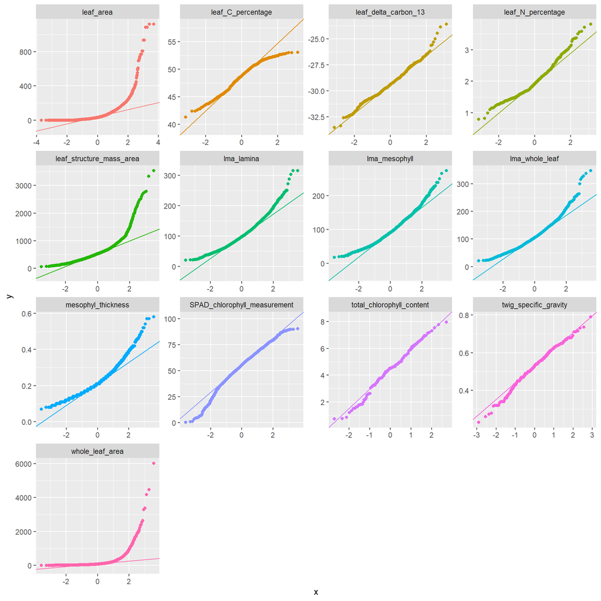

```r
ggqq_plots <- ggplot(data = all_traits,
       mapping = aes(sample = traitvalue,
                     colour = trait)) +
  stat_qq() +
  stat_qq_line() +
  facet_wrap(~ trait, scales = "free") +
  guides(colour = "none")

ggqq_plots
```

# Leaf level

## Leaf Mass Per Area

All leaves.

```r
gg_lma1 <-
  ggplot() +
  geom_point(data = traits_leaf_level,
             mapping = aes(x = t_lma_mesophyll,
                           y = t_lma_whole_leaf,
                           color = tax_sp_level,
                           shape = leaf_maturity)) +
  geom_abline(slope = 1, intercept = 0) +
  scale_x_continuous(trans='log10') +
  scale_y_continuous(trans='log10') +
  xlab(label = "log10(lma mesophyll scale)") +
  ylab(label = "log10(lma whole leaf scale)") +
  guides(color = "none")

plotly::ggplotly(gg_lma1)
```

[interactive chart not shown]

Averaging across leaves per cohort.

```r
gg_lma1 <-
  ggplot() +
  geom_point(data = traits_leaf_level_averaged,
             mapping = aes(x = t_lma_mesophyll,
                           y = t_lma_whole_leaf,
                           color = tax_sp_level,
                           shape = leaf_maturity)) +
  geom_abline(slope = 1, intercept = 0) +
  scale_x_continuous(trans='log10') +
  scale_y_continuous(trans='log10') +
  xlab(label = "log10(lma mesophyll scale)") +
  ylab(label = "log10(lma whole leaf scale)") +
  guides(color = "none")

plotly::ggplotly(gg_lma1)
```

[interactive chart not shown]

```r
gg_lma2 <-
  ggplot() +
  geom_point(data = traits_leaf_level,
             mapping = aes(x = t_lma_lamina,
                           y = t_lma_whole_leaf,
                           color = tax_sp_level,
                           shape = leaf_maturity)) +
  geom_abline(slope = 1, intercept = 0) +
  scale_x_continuous(trans='log10') +
  scale_y_continuous(trans='log10') +
  xlab(label = "log10(lma lamina scale)") +
  ylab(label = "log10(lma whole leaf scale)") +
  guides(color = "none")


plotly::ggplotly(gg_lma2)
```

[interactive chart not shown]

Averaging across leaves per cohort.

```r
gg_lma2 <-
  ggplot() +
  geom_point(data = traits_leaf_level_averaged,
             mapping = aes(x = t_lma_lamina,
                           y = t_lma_whole_leaf,
                           color = tax_sp_level,
                           shape = leaf_maturity)) +
  geom_abline(slope = 1, intercept = 0) +
  scale_x_continuous(trans='log10') +
  scale_y_continuous(trans='log10') +
  xlab(label = "log10(lma lamina scale)") +
  ylab(label = "log10(lma whole leaf scale)") +
  guides(color = "none")


plotly::ggplotly(gg_lma2)
```

[interactive chart not shown]

```r
gg_lma3 <-
  ggplot() +
  geom_point(data = traits_leaf_level,
             mapping = aes(x = t_lma_lamina,
                           y = t_mesophyl_thickness,
                           color = tax_sp_level,
                           shape = leaf_maturity)) +
  scale_x_continuous(trans='log10') +
  scale_y_continuous(trans='log10') +
  xlab(label = "log10(lma lamina scale)") +
  ylab(label = "log10(mesophyl_thickness)") +
  guides(color = "none")


plotly::ggplotly(gg_lma3)
```

[interactive chart not shown]

```r
gg_lma4 <-
  ggplot() +
  geom_point(data = traits_leaf_level,
             mapping = aes(x = t_lma_lamina,
                           y = t_leaf_structure_mass_area,
                           color = tax_sp_level,
                           shape = leaf_maturity)) +
  scale_x_continuous(trans='log10') +
  scale_y_continuous(trans='log10') +
  xlab(label = "log10(lma lamina scale)") +
  ylab(label = "log10(leaf_structure_mass_area)") +
  guides(color = "none")


plotly::ggplotly(gg_lma4)
```

[interactive chart not shown]

## Ratio of LMA at mesophyl scale and LMA at the whole leaf scale

Can we express this ratio as a proxy of construction costs to non photosynthetic tissues ?

```r
LMA_ratios <-
  traits_leaf_level %>%
  select(
    starts_with("t_lma"),
    leaf_id,
    colnbr,
    voucher_type,
    tax_sp_level,
    cohort_id,
    leaf_maturity,
    t_leaf_area,
    t_whole_leaf_area,
    t_leaf_C_percentage
  ) %>%
  mutate(
    ratio_lma_lamina_meso =
      round((t_lma_lamina - t_lma_mesophyll) / t_lma_lamina * 100, 1),
    ratio_lma_whole_lamina =
      round((t_lma_whole_leaf - t_lma_lamina) / t_lma_whole_leaf * 100, 1),
    ratio_lma_whole_meso =
      round((t_lma_whole_leaf - t_lma_mesophyll) / t_lma_whole_leaf * 100, 1)
  ) %>%
  group_by(cohort_id, colnbr) %>% ### averaged across leaves per cohort
  summarise(
    across(starts_with("ratio_lma"), ~ round(mean(., na.rm = T), 1)),
    across(starts_with("t_lma"), ~ round(mean(., na.rm = T), 1)),
    tax_sp_level = first(tax_sp_level),
    leaf_maturity = first(leaf_maturity),
    t_leaf_area = mean(t_leaf_area, na.rm = T),
    t_whole_leaf_area = mean(t_whole_leaf_area, na.rm = T),
    t_leaf_C_percentage = mean(t_leaf_C_percentage, na.rm = T)
  ) %>%
  filter(!is.na(ratio_lma_whole_meso)) %>%
  ungroup()
```

How this ratio correlates with leaf area.

```r
gg_lma4 <-
  ggplot() +
  geom_point(data = LMA_ratios,
             mapping = aes(x = t_whole_leaf_area ,
                           y = ratio_lma_whole_meso,
                           color = tax_sp_level,
                           shape = leaf_maturity)) +
  scale_x_continuous(trans='log10') +
  xlab(label = "log10(whole leaf area)") +
  ylab(label = "Ratio LMA mesophyl/LMA whole leaf") +
  guides(color = "none")


plotly::ggplotly(gg_lma4)
```

[interactive chart not shown]

How this ratio correlates with leaf C carbon.

```r
gg_lma4 <-
  ggplot() +
  geom_point(data = LMA_ratios,
             mapping = aes(x = t_leaf_C_percentage ,
                           y = ratio_lma_whole_meso,
                           color = tax_sp_level,
                           shape = leaf_maturity)) +
  scale_x_continuous(trans='log10') +
  xlab(label = "log10(leaf C content)") +
  ylab(label = "Ratio LMA mesophyl/LMA whole leaf") +
  guides(color = "none")


plotly::ggplotly(gg_lma4)
```

[interactive chart not shown]

## Nitrogen content and LMA

### The whole dataset

```r
gg_lma2 <-
  ggplot() +
  geom_point(data = traits_leaf_level,
             mapping = aes(x = t_lma_mesophyll,
                           y = t_leaf_N_percentage,
                           color = tax_sp_level,
                           shape = leaf_maturity)) +
  geom_abline(slope = 1, intercept = 0) +
  scale_x_continuous(trans='log10') +
  scale_y_continuous(trans='log10') +
  xlab(label = "log10(lma mesophyl scale)") +
  ylab(label = "log10(Nitrogen content)") +
  guides(color = "none")


plotly::ggplotly(gg_lma2)
```

[interactive chart not shown]

### Within species

```r
## select the four most sampled species
selected_sp <-
  traits_leaf_level %>%
  filter(!is.na(tax_sp_level)) %>%
  group_by(tax_sp_level) %>%
  count() %>%
  arrange(desc(n))%>%
  ungroup() %>%
  slice(1:4)

dataset_filtered <-
  traits_leaf_level %>%
  filter(tax_sp_level %in% selected_sp$tax_sp_level) %>%
  mutate(leaf_maturity = replace_na(leaf_maturity, "unkown")) %>%
  group_by(leaf_id, colnbr, tax_sp_level, voucher_type) %>%
  summarise(t_lma_mesophyll = mean(t_lma_mesophyll, na.rm = T),
            t_leaf_N_percentage = mean(t_leaf_N_percentage, na.rm = T),
            leaf_maturity = first(leaf_maturity, na_rm = T)) %>%
  filter(!is.na(t_lma_mesophyll),
         !is.na(t_leaf_N_percentage))

gg_w <-
  ggplot(data = dataset_filtered,
         aes(x = t_lma_mesophyll,
             y = t_leaf_N_percentage,
             color = tax_sp_level,
             shape = leaf_maturity)) +
    geom_point() +
  scale_x_continuous(trans='log10') +
  scale_y_continuous(trans='log10') +
  geom_smooth(method = "lm",
                se = FALSE,
                mapping = aes(group = tax_sp_level)) +
    labs(title = "Within-species",
         x = "log(LMA mesophyll scale)",
         y = "log(N content per dry mass (%))") +
    theme_minimal()


plotly::ggplotly(gg_w)
```

[interactive chart not shown]

## Carbon content and LMA

```r
gg_lma2 <-
  ggplot() +
  geom_point(data = traits_leaf_level,
             mapping = aes(x = t_lma_mesophyll,
                           y = t_leaf_C_percentage,
                           color = tax_sp_level,
                           shape = leaf_maturity)) +
  scale_x_continuous(trans='log10') +
  scale_y_continuous(trans='log10') +
  xlab(label = "log10(lma mesophyl scale)") +
  ylab(label = "log10(Carbon content)") +
  guides(color = "none")


plotly::ggplotly(gg_lma2)
```

[interactive chart not shown]

## Total chlorophyll content and SPAD measurement

| measurementmethod | measurementremarks |
| --- | --- |
| maceration 50mg of leaf sample in 80% Acetone, centrifuging and spectrophotometric reading of absorbances at the various wavelengths to determine chlorophyll a and b | Measures were done on silica-dried samples in the field. Lab work was done at IITA under the supervision of Rose Ndango |

```r
gg1 <- ggplot() +
  geom_point(data = traits_leaf_level,
             mapping = aes(x = t_total_chlorophyll_content,
                           y = t_SPAD_chlorophyll_measurement,
                           color = tax_sp_level,
                           fill = tax_sp_level,
                           shape = leaf_maturity)) +
  guides(color = "none",
         fill = "none",
         shape = "none")

plotly::ggplotly(gg1)
```

[interactive chart not shown]

## Total chlorophyll content and Nitrogen content

```r
gg1 <- ggplot() +
  geom_point(data = traits_leaf_level,
             mapping = aes(x = t_total_chlorophyll_content,
                           y = t_leaf_N_percentage,
                           color = tax_sp_level,
                           fill = tax_sp_level,
                           shape = leaf_maturity)) +
  guides(color = "none",
         fill = "none",
         shape = "none")

plotly::ggplotly(gg1)
```

[interactive chart not shown]

## Total chlorophyll content and stable delta 13C isotope

```r
gg1 <- ggplot() +
  geom_point(data = traits_leaf_level,
             mapping = aes(x = t_total_chlorophyll_content,
                           y = t_leaf_delta_carbon_13,
                           color = tax_sp_level,
                           fill = tax_sp_level,
                           shape = leaf_maturity)) +
  guides(color = "none",
         fill = "none",
         shape = "none")

plotly::ggplotly(gg1)
```

[interactive chart not shown]

# Species level

## Grouping by species

```r
colnbr_per_sp <-
  traits_leaf_level %>%
  filter(leaf_maturity != "immature" |
           is.na(leaf_maturity)) %>%  ## excluding immature leaf for species level
  group_by(voucher_type, colnbr, tag, id_data_individuals, plot_name) %>%
  summarise(
    tax_sp_level = first(tax_sp_level),
    across(starts_with("t_"), ~ mean(., na.rm = TRUE)),
    plot_name = first(plot_name)
  )
```

[output not shown]

```r
writexl::write_xlsx(colnbr_per_sp %>% filter(!is.na(tax_sp_level)), "colnbr_per_sp.xlsx")

traits_taxa <-
  colnbr_per_sp %>%
  group_by(tax_sp_level) %>%
  summarise(nbe_voucher = n(),
            across(starts_with("t_"), ~ mean(., na.rm = TRUE))) %>%
  left_join(LMA_ratios %>%
              group_by(tax_sp_level) %>%
              summarise(t_ratio_lma_whole_meso = mean(ratio_lma_whole_meso, na.rm = T))) %>%
  filter(!grepl("indet", tax_sp_level),
         !is.na(tax_sp_level))
traits_taxa_sel <-
  traits_taxa %>%
  select(
    tax_sp_level,
    t_lma_lamina,
    t_lma_mesophyll,
    t_lma_whole_leaf,
    t_mesophyl_thickness,
    t_SPAD_chlorophyll_measurement,
    t_leaf_area,
    t_leaf_structure_mass_area,
    t_twig_specific_gravity,
    t_leaf_N_percentage,
    t_leaf_C_percentage,
    t_ratio_lma_whole_meso
  ) %>%
  mutate(lma = ifelse(is.na(t_lma_lamina), t_lma_mesophyll, t_lma_lamina)) %>% ## taking lma mesophyll if no lma lamina available
  mutate(lma = ifelse(is.na(lma), t_lma_whole_leaf, lma)) %>% ## taking lma whole leaf if no lma mesophyll available
  select(-starts_with("t_lma")) %>%
  rename(t_lma = lma)
```

## Getting succession guild information

```r
guilds <-
  query_taxa_traits(trait_ids = 9, format = "wide", add_taxa_info = T)
```

```
## ── Querying taxa-level traits ──
```

```
## ℹ Fetching trait measurements for trait(s): 9
```

```
## ✔ Found 1622 measurement(s) for 608 taxa
```

```
## ℹ Resolving taxonomic synonyms
```

```
## ℹ Including synonyms: 608 taxa expanded to 2499 taxa
```

```
## ℹ Adding taxonomic information
```

```
## ── Processing traits to wide format ──
```

```
## ℹ Aggregating categorical traits (mode)
```

```
## ℹ Adding taxonomic information
```

```
## ✔ Query completed
```

```r
guilds <-
  guilds$traits_categorical


guilds_wide <-
  query_traits_measures(id_trait = 9, pivot_table = F, add_taxa_info = T)
```

```
## ℹ Using legacy wrapper - consider migrating to query_taxa_traits()
```

```
## ── Querying taxa-level traits ──
```

```
## ℹ Fetching trait measurements for trait(s): 9
```

```
## ✔ Found 1622 measurement(s) for 608 taxa
```

```
## ℹ Resolving taxonomic synonyms
```

```
## ℹ Including synonyms: 608 taxa expanded to 2499 taxa
```

```
## ℹ Adding taxonomic information
```

```
## ✔ Query completed
```

```r
guilds_wide <-
  guilds_wide$traits_found


writexl::write_xlsx(guilds, "guilds.xlsx")
writexl::write_xlsx(guilds_wide, "guilds_wide.xlsx")
```

## Get maximum diameter values for all species

```r
all_diameters <-
  query_individual_features(trait_ids = 1, format = "wide", include_individuals = T)
```

```
## ── Fetching trait measurements ──
```

```
## ℹ Removed 8194 measurement(s) with issues
```

```
## ── Pivoting to wide format ──
```

```
## ℹ Fetching linked individuals
```

```
## ℹ Processing 13 chunk(s) for linked individuals
```

```
## ✔ Fetched 361807 individual record(s)
```

```
## ✔ Query completed: 412825 measurement(s)
```

```r
## extract all values
all_values <-
  all_diameters$features

linked_individuals <-
  all_diameters$individuals %>%
  select(id_n, idtax_individual_f, tax_sp_level, tax_fam)

## Get the maximum and the percentile 95 of stem_diameter for all species
taxa_level_stem_diameters <-
  all_values %>%
  select(stem_diameter, id_data_individuals) %>%
  left_join(
    linked_individuals,
    by = c("id_data_individuals" = "id_n")
  ) %>%
  filter(!is.na(idtax_individual_f)) %>%
  group_by(id_data_individuals) %>% ### if more than one diameter value linked to an individual, take the maximal value. This happens if the individual has been censused more than once.
  summarise(
    tax_sp_level = first(tax_sp_level),
    tax_fam = first(tax_fam),
    stem_diameter = max(stem_diameter)
  ) %>%
  group_by(tax_sp_level, tax_fam) %>% ### summary by species
  summarise(
    max_stem_diameter = max(stem_diameter), ## take the highest recorded value
    t_dbh_095 = quantile(stem_diameter, 0.95), ## take the percentile 0.95
    nbe_values = n() ## number of values
  ) %>%
  filter(!is.na(tax_sp_level)) %>%
  ungroup()
```

```r
traits_taxa_sel <-
  traits_taxa_sel %>%
  left_join(taxa_level_stem_diameters %>%
              select(t_dbh_095, tax_sp_level),
            by = c("tax_sp_level" = "tax_sp_level"))

## add guild

traits_taxa_sel <-
  traits_taxa_sel %>%
  left_join(guilds %>% rename(guild = taxa_succession_guild) %>%
              select(guild, tax_infra_level),
            by = c("tax_sp_level" = "tax_infra_level"))


colnbr_per_sp <-
  colnbr_per_sp %>%
  ungroup() %>%
  left_join(meta_data %>%
              select(locality_name, plot_name))
synthetic_table_bou_mba <-
  colnbr_per_sp %>%
  ### keep only data identified to species level
  filter(!is.na(tax_sp_level)) %>%
  ### select columns of interest
  select(tax_sp_level, starts_with("t_"), locality_name) %>%
  pivot_longer(
    cols = starts_with("t_"),
    names_to = "trait",
    values_to = "value"
  ) %>%
  group_by(tax_sp_level, trait, locality_name) %>%
  summarise(
    mean = mean(value, na.rm = TRUE),
    sd   = sd(value, na.rm = TRUE),
    n    = sum(!is.na(value)),
    .groups = "drop"
  ) %>%
  pivot_wider(
    names_from = locality_name,
    values_from = c(mean, sd, n),
    names_sep = "_"
  )


### filter for non null trait measurements
synthetic_table_bou_mba <-
  synthetic_table_bou_mba %>%
  filter(n_Bouamir > 0,
         !is.na(n_Bouamir),
         n_Mbalmayo > 0,
         !is.na(n_Mbalmayo)) %>%
  arrange(trait)

writexl::write_xlsx(synthetic_table_bou_mba, "synthetic_table_bou_mba.xlsx")
```

## Quantile-quantile plots

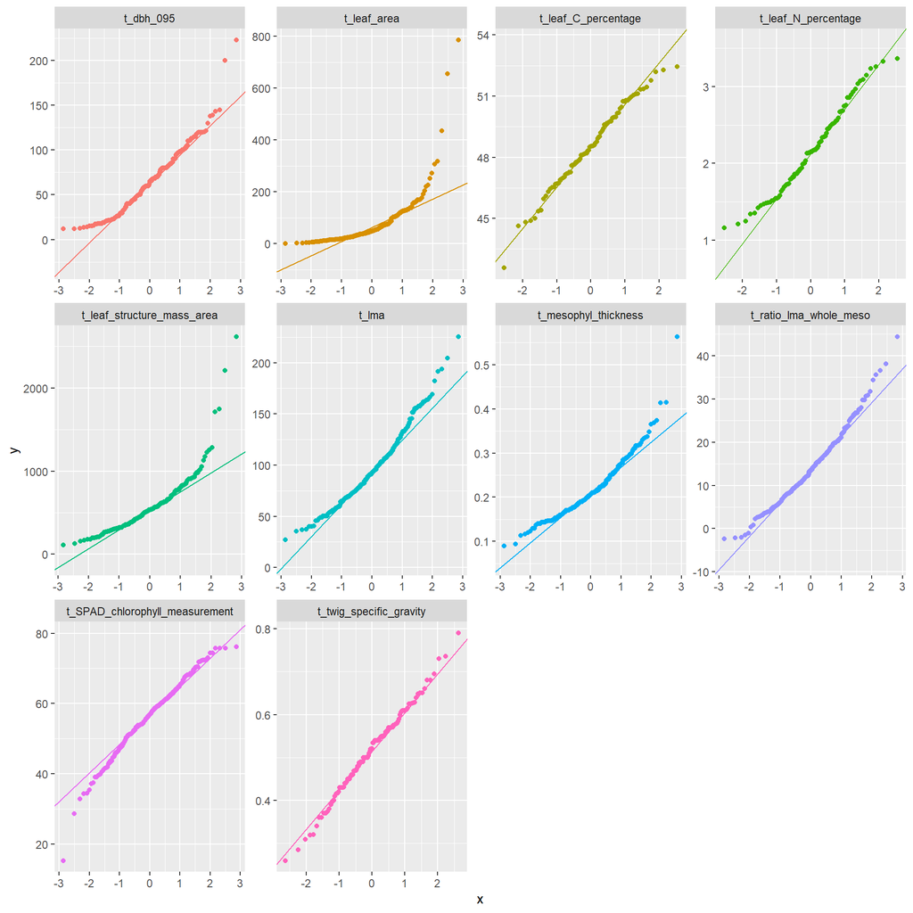

```r
traits_taxa_sel_pivot <-
  traits_taxa_sel %>%
  pivot_longer(cols = starts_with("t_"), names_to = "trait") %>%
  filter(!is.na(value))

ggqq_plots <-
  ggplot(data = traits_taxa_sel_pivot,
       mapping = aes(sample = value,
                     colour = trait)) +
  stat_qq() +
  stat_qq_line() +
  facet_wrap(~ trait, scales = "free") +
  guides(colour = "none")

ggqq_plots
```

## PCA leaves economic spectra

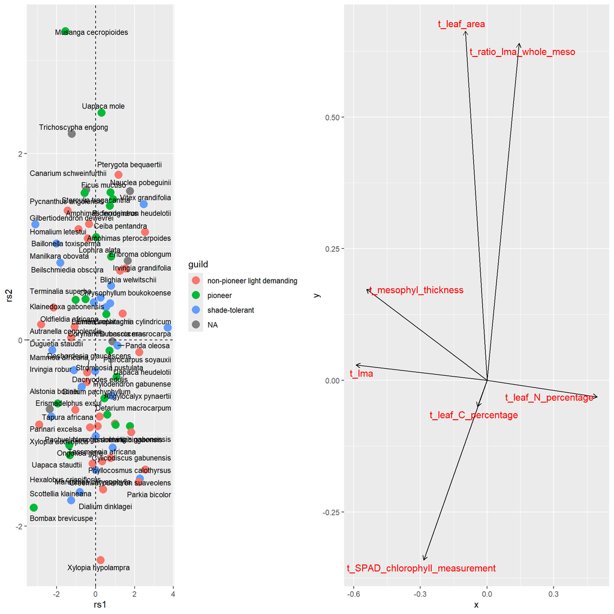

```r
traits_taxa_sel_filtered <-
  traits_taxa_sel %>%
  select(-t_twig_specific_gravity,
         -t_dbh_095,
         -t_leaf_structure_mass_area) %>%
  rename(ratio_lma_whole_meso = t_ratio_lma_whole_meso) %>%
  rowwise() %>%
  filter(!any(is.na(c_across(where( ### keeping only species where all traits are available
    is.numeric
  ))))) %>%
  mutate(across(starts_with("t_"), ~ log10(.x))) %>% ## log transformation
  ungroup() %>%
  rename(t_ratio_lma_whole_meso = ratio_lma_whole_meso)

pca_res <- dudi.pca(
  df = traits_taxa_sel_filtered %>%
    select(where(is.numeric)),
  scannf = FALSE,
  nf = 2,
  center = TRUE
)

pca_res_tax <- tibble(tax_sp_level = traits_taxa_sel_filtered$tax_sp_level,
                      rs1 = pca_res$li$Axis1,
                      rs2 = pca_res$li$Axis2,
                      guild = traits_taxa_sel_filtered$guild)

env_scores <- tibble(var = rownames(pca_res$c1),
                     rs1 = pca_res$c1$CS1, rs2 = pca_res$c1$CS2)

pca_1 <- ggplot() +
  geom_point(
    data = pca_res_tax,
    mapping = aes(x = rs1, y = rs2,
                  colour = guild),
    size = 4
  ) +
  ggrepel::geom_text_repel(
    data = pca_res_tax,
    aes(x = rs1, y = rs2, label = tax_sp_level),
    size = 3,
    color = "black"
  )  +
  geom_hline(yintercept = 0, linetype = "dashed") +
  geom_vline(xintercept = 0, linetype = "dashed")

pca_1_env <-
  ggplot() +
  geom_segment(
    data = env_scores,
    aes(
      x = 0,
      y = 0,
      xend = rs1,
      yend = rs2
    ),
    arrow = arrow(length = unit(0.2, "cm"))
  ) +
  ggrepel::geom_text_repel(
    data = env_scores,
    aes(x = rs1, y = rs2, label = var),
    size = 4,
    color = "red"
  )

gridExtra::grid.arrange(pca_1, pca_1_env, ncol = 2)
```

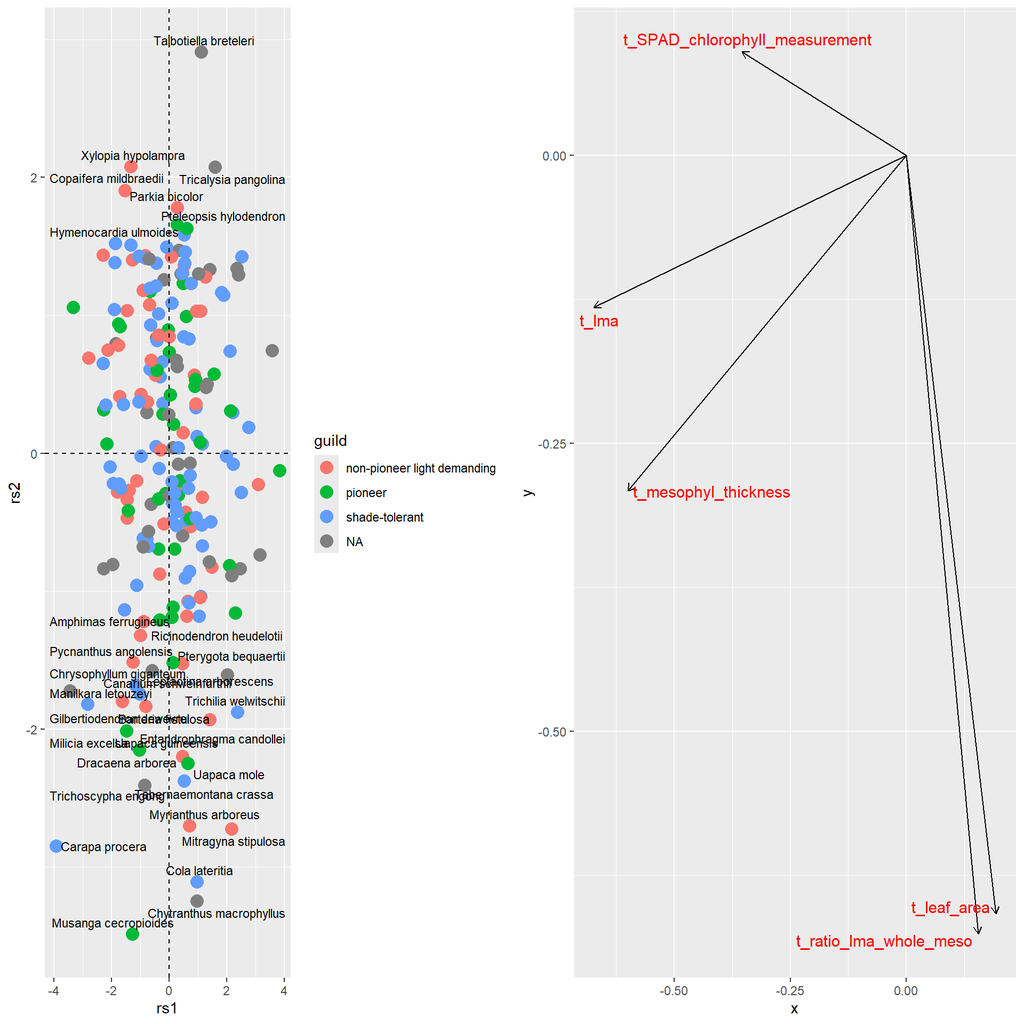

```r
traits_taxa_sel_filtered <-
  traits_taxa_sel %>%
  select(-t_twig_specific_gravity,
         -t_dbh_095,
         -t_leaf_structure_mass_area,
         -t_leaf_C_percentage,
         -t_leaf_N_percentage) %>%
  rename(ratio_lma_whole_meso = t_ratio_lma_whole_meso) %>%
  rowwise() %>%
  filter(!any(is.na(c_across(where( ### keeping onlue species where all traits are available
    is.numeric
  ))))) %>%
  mutate(across(starts_with("t_"), ~ log10(.x))) %>% ## log transformation
  ungroup() %>%
  rename(t_ratio_lma_whole_meso = ratio_lma_whole_meso)

pca_res <- dudi.pca(
  df = traits_taxa_sel_filtered %>% select(where(is.numeric)),
  scannf = FALSE,
  nf = 2,
  center = TRUE
)

pca_res_tax <- tibble(tax_sp_level = traits_taxa_sel_filtered$tax_sp_level,
                      rs1 = pca_res$li$Axis1,
                      rs2 = pca_res$li$Axis2,
                      guild = traits_taxa_sel_filtered$guild)

env_scores <- tibble(var = rownames(pca_res$c1),
                     rs1 = pca_res$c1$CS1, rs2 = pca_res$c1$CS2)


pca_1 <- ggplot() +
  geom_point(
    data = pca_res_tax,
    mapping = aes(x = rs1, y = rs2,
                  colour = guild),
    size = 4
  ) +
  ggrepel::geom_text_repel(
    data = pca_res_tax,
    aes(x = rs1, y = rs2, label = tax_sp_level),
    size = 3,
    color = "black"
  )  +
  geom_hline(yintercept = 0, linetype = "dashed") +
  geom_vline(xintercept = 0, linetype = "dashed")

pca_1_env <-
  ggplot() +
  geom_segment(
    data = env_scores,
    aes(
      x = 0,
      y = 0,
      xend = rs1,
      yend = rs2
    ),
    arrow = arrow(length = unit(0.2, "cm"))
  ) +
  ggrepel::geom_text_repel(
    data = env_scores,
    aes(x = rs1, y = rs2, label = var),
    size = 4,
    color = "red"
  )

gridExtra::grid.arrange(pca_1, pca_1_env, ncol = 2)
```

## PCA including twig wood density

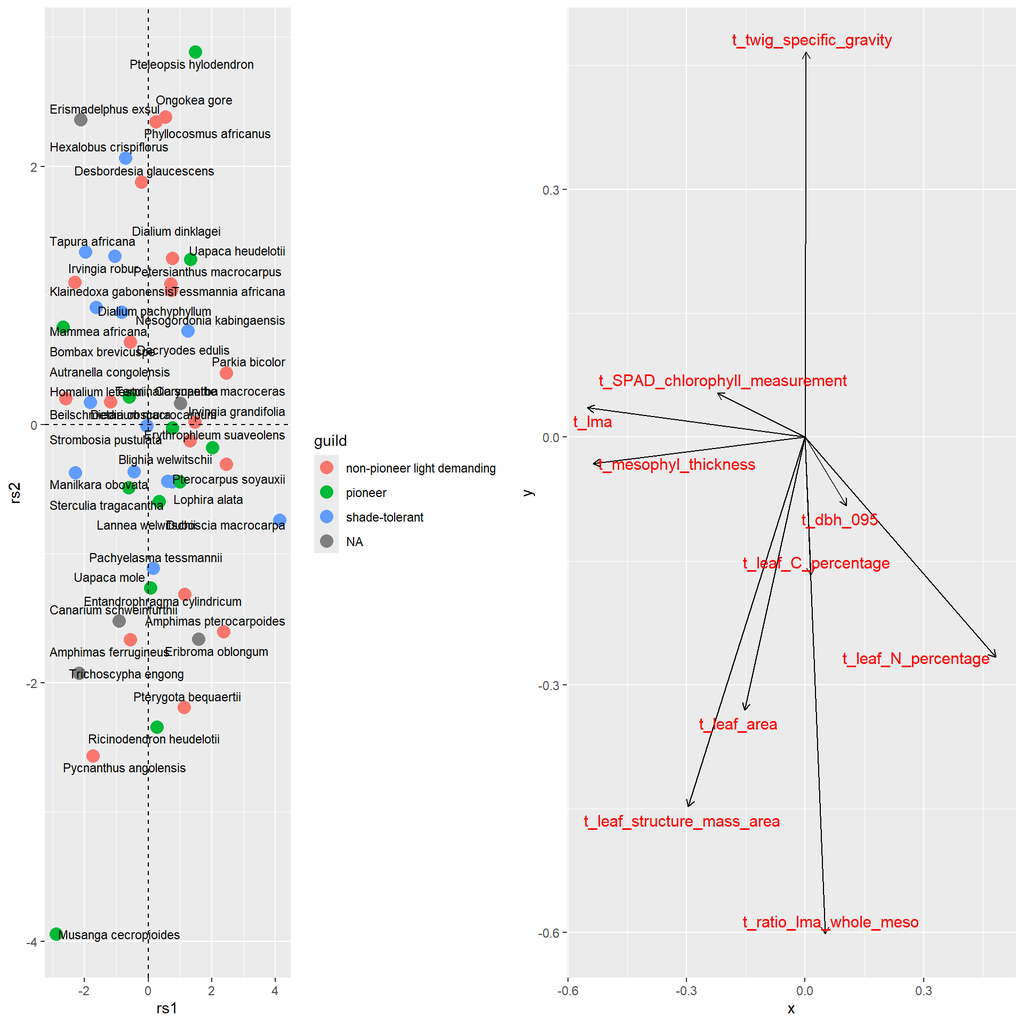

```r
traits_taxa_sel_filtered <-
  traits_taxa_sel %>%
  rowwise() %>%
  filter(!any(is.na(c_across(where( ### keeping onlue species where all traits are available
    is.numeric
  ))))) %>%
  mutate(across(where(is.numeric), ~ log10(.x))) %>% ## log transformation
  ungroup()

pca_res <- dudi.pca(
  df = traits_taxa_sel_filtered %>% select(where(is.numeric)),
  scannf = FALSE,
  nf = 2,
  center = TRUE
)

pca_res_tax <- tibble(tax_sp_level = traits_taxa_sel_filtered$tax_sp_level,
                      rs1 = pca_res$li$Axis1,
                      rs2 = pca_res$li$Axis2,
                      guild = traits_taxa_sel_filtered$guild)

env_scores <- tibble(var = rownames(pca_res$c1),
                     rs1 = pca_res$c1$CS1, rs2 = pca_res$c1$CS2)


pca_1 <- ggplot() +
  geom_point(
    data = pca_res_tax,
    mapping = aes(x = rs1, y = rs2,
                  colour = guild),
    size = 4
  ) +
  ggrepel::geom_text_repel(
    data = pca_res_tax,
    aes(x = rs1, y = rs2, label = tax_sp_level),
    size = 3,
    color = "black"
  )  +
  geom_hline(yintercept = 0, linetype = "dashed") +
  geom_vline(xintercept = 0, linetype = "dashed")

pca_1_env <-
  ggplot() +
  geom_segment(
    data = env_scores,
    aes(
      x = 0,
      y = 0,
      xend = rs1,
      yend = rs2
    ),
    arrow = arrow(length = unit(0.2, "cm"))
  ) +
  ggrepel::geom_text_repel(
    data = env_scores,
    aes(x = rs1, y = rs2, label = var),
    size = 4,
    color = "red"
  )

gridExtra::grid.arrange(pca_1, pca_1_env, ncol = 2)
```

## PCA including twig wood density without N and C

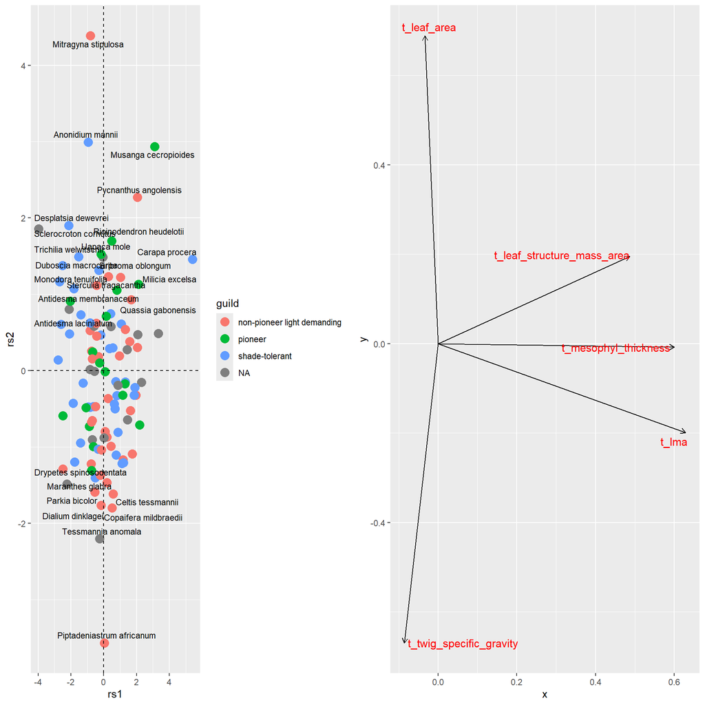

```r
traits_taxa_sel_filtered <-
  traits_taxa_sel %>%
  select(-t_dbh_095,
          -t_ratio_lma_whole_meso,
         -t_leaf_C_percentage,
         -t_leaf_N_percentage,
         -t_SPAD_chlorophyll_measurement) %>%
  rowwise() %>%
  filter(!any(is.na(c_across(where( ### keeping onlue species where all traits are available
    is.numeric
  ))))) %>%
  mutate(across(where(is.numeric), ~ log10(.x))) %>% ## log transformation
  ungroup()

pca_res <- dudi.pca(
  df = traits_taxa_sel_filtered %>% select(where(is.numeric)),
  scannf = FALSE,
  nf = 3,
  center = TRUE
)

pca_res_tax <- tibble(tax_sp_level = traits_taxa_sel_filtered$tax_sp_level,
                      rs1 = pca_res$li$Axis1,
                      rs2 = pca_res$li$Axis2,
                      rs3 = pca_res$li$Axis3,
                      guild = traits_taxa_sel_filtered$guild)

env_scores <- tibble(var = rownames(pca_res$c1),
                     rs1 = pca_res$c1$CS1,
                     rs2 = pca_res$c1$CS2,
                     rs3 = pca_res$c1$CS3)


pca_1 <- ggplot() +
  geom_point(
    data = pca_res_tax,
    mapping = aes(x = rs1, y = rs2,
                  colour = guild),
    size = 4
  ) +
  ggrepel::geom_text_repel(
    data = pca_res_tax,
    aes(x = rs1, y = rs2, label = tax_sp_level),
    size = 3,
    color = "black"
  )  +
  geom_hline(yintercept = 0, linetype = "dashed") +
  geom_vline(xintercept = 0, linetype = "dashed")

pca_1_env <-
  ggplot() +
  geom_segment(
    data = env_scores,
    aes(
      x = 0,
      y = 0,
      xend = rs1,
      yend = rs2
    ),
    arrow = arrow(length = unit(0.2, "cm"))
  ) +
  ggrepel::geom_text_repel(
    data = env_scores,
    aes(x = rs1, y = rs2, label = var),
    size = 4,
    color = "red"
  )

gridExtra::grid.arrange(pca_1, pca_1_env, ncol = 2)
```

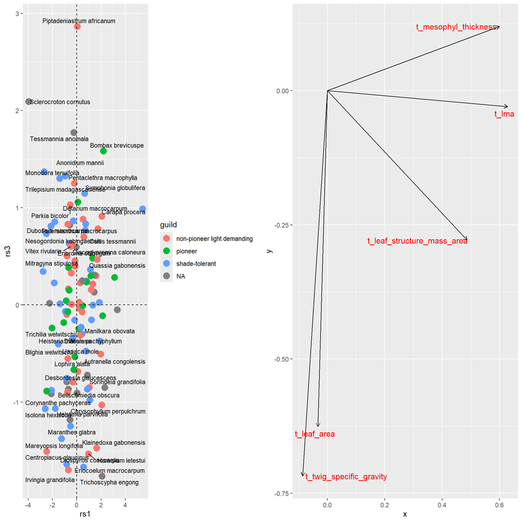

```r
pca_2 <- ggplot() +
  geom_point(
    data = pca_res_tax,
    mapping = aes(x = rs1, y = rs3,
                  colour = guild),
    size = 4
  ) +
  ggrepel::geom_text_repel(
    data = pca_res_tax,
    aes(x = rs1, y = rs3, label = tax_sp_level),
    size = 3,
    color = "black"
  )  +
  geom_hline(yintercept = 0, linetype = "dashed") +
  geom_vline(xintercept = 0, linetype = "dashed")

pca_2_env <-
  ggplot() +
  geom_segment(
    data = env_scores,
    aes(
      x = 0,
      y = 0,
      xend = rs1,
      yend = rs3
    ),
    arrow = arrow(length = unit(0.2, "cm"))
  ) +
  ggrepel::geom_text_repel(
    data = env_scores,
    aes(x = rs1, y = rs3, label = var),
    size = 4,
    color = "red"
  )

gridExtra::grid.arrange(pca_2, pca_2_env, ncol = 2)
```

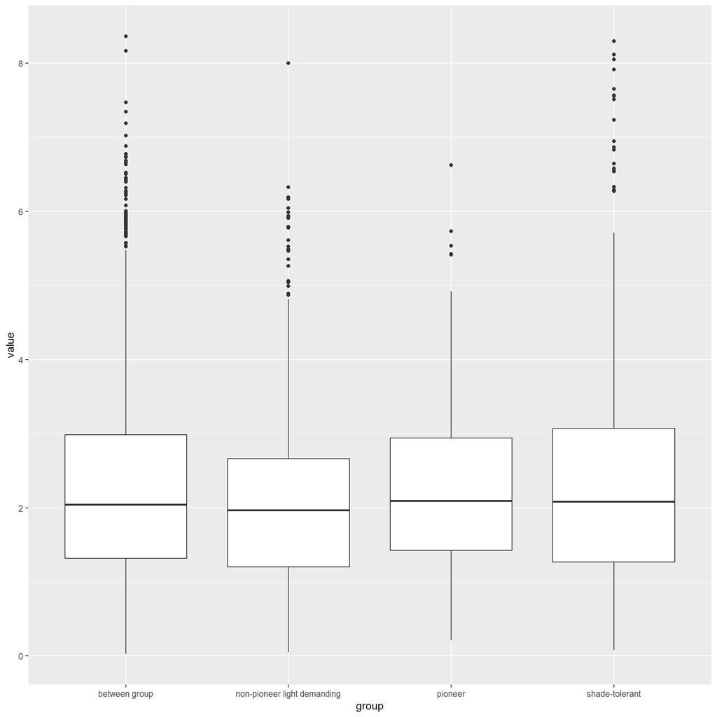

```r
pca_df <- pca_res_tax %>%
  select(tax_sp_level, rs1, rs2) %>%
  column_to_rownames("tax_sp_level")

mat <- as.matrix(dist(pca_df))
idx <- which(lower.tri(mat), arr.ind = TRUE)
mat <- tibble(
  tax_sp_level_1 = rownames(mat)[idx[, 1]],
  tax_sp_level_2 = colnames(mat)[idx[, 2]],
  value = mat[idx]
)

mat <-
  mat %>%
  left_join(guilds %>% rename(guild_1 = taxa_succession_guild) %>%
              select(guild_1, tax_infra_level),
            by = c("tax_sp_level_1" = "tax_infra_level")) %>%
  left_join(guilds %>% rename(guild_2 = taxa_succession_guild) %>%
              select(guild_2, tax_infra_level),
            by = c("tax_sp_level_2" = "tax_infra_level"))

within_group_dist <-
  mat %>%
  filter(guild_1 == guild_2) %>%
  mutate(group = guild_2)

between_group_dist <-
  mat %>%
  filter(guild_1 != guild_2) %>%
  mutate(group = "between group")


bind_rows(within_group_dist, between_group_dist) %>%
  ggplot(aes(x = group, y = value)) +
  geom_boxplot()
```

```r
anova_result <- aov(value ~ group, data = bind_rows(within_group_dist, between_group_dist) )
summary(anova_result)
```

```
          Df Sum Sq Mean Sq F value  Pr(>F)
```

group 3 23 7.627 4.516 0.00362 ** Residuals 4274 7218 1.689  
— Signif. codes: 0 ‘**’ 0.001 ’**’ 0.01 ’’ 0.05 ‘.’ 0.1 ’ ’ 1

```r
tukey_result <- TukeyHSD(aov(value ~ group, data = bind_rows(within_group_dist, between_group_dist)))
tukey_result
```

Tukey multiple comparisons of means 95% family-wise confidence level

Fit: aov(formula = value ~ group, data = bind_rows(within_group_dist, between_group_dist))

$group diff lwr upr non-pioneer light demanding-between group -0.177295921 -0.32150606 -0.03308578 pioneer-between group 0.007999139 -0.26940892 0.28540719 shade-tolerant-between group 0.066289242 -0.07483140 0.20740988 pioneer-non-pioneer light demanding 0.185295061 -0.11413242 0.48472254 shade-tolerant-non-pioneer light demanding 0.243585163 0.06298444 0.42418588 shade-tolerant-pioneer 0.058290102 -0.23966171 0.35624192 p adj non-pioneer light demanding-between group 0.0086421 pioneer-between group 0.9998541 shade-tolerant-between group 0.6222587 pioneer-non-pioneer light demanding 0.3841633 shade-tolerant-non-pioneer light demanding 0.0029923 shade-tolerant-pioneer 0.9584310

# State of sampling per observatory

```r
all_traits %>%
  group_by(plot_name, trait) %>%
  filter(grepl("_observatory", plot_name)) %>%
  count() %>%
  pivot_wider(names_from = plot_name,
              values_from = n) %>%
  gt::gt()
```

| bouamir_pheno_observatory | loundoungou_pheno_observatory | mbalmayo_pheno_observatory |
| --- | --- | --- |
| SPAD_chlorophyll_measurement |  |  |
| 740 | 269 | 1019 |
| leaf_C_percentage |  |  |
| 74 | NA | 476 |
| leaf_N_percentage |  |  |
| 74 | NA | 476 |
| leaf_area |  |  |
| 1643 | 261 | 1206 |
| leaf_delta_carbon_13 |  |  |
| 74 | NA | 476 |
| leaf_structure_mass_area |  |  |
| 683 | NA | 617 |
| lma_lamina |  |  |
| 724 | 261 | 824 |
| lma_mesophyll |  |  |
| 702 | 244 | 699 |
| lma_whole_leaf |  |  |
| 721 | 265 | 730 |
| mesophyl_thickness |  |  |
| 743 | 271 | 1011 |
| twig_specific_gravity |  |  |
| 90 | NA | 134 |
| whole_leaf_area |  |  |
| 721 | 265 | 729 |
| total_chlorophyll_content |  |  |
| NA | NA | 152 |

```r
nbe_tree_sampled <-
  traits_leaf_level %>%
  filter(grepl("_observatory", plot_name)) %>%
  group_by(plot_name, tag) %>%
  count() %>%
  ungroup() %>%
  group_by(plot_name) %>%
  summarise(nbe_tree_sampled = n())

colnbr_per_sp %>%
  filter(grepl("observatory", plot_name)) %>%
  group_by(plot_name) %>%
  summarise(nbe_pheno_tree = n()) %>%
  left_join(nbe_tree_sampled) %>%
  gt::gt(caption = "Number of pheno_tree and tree sampled per observatory")
```

Number of pheno_tree and tree sampled per observatory

| plot_name | nbe_pheno_tree | nbe_tree_sampled |
| --- | --- | --- |
| bouamir_pheno_observatory | 165 | 155 |
| mbalmayo_pheno_observatory | 258 | 181 |

```r
sampled_per_observatory <-
  colnbr_per_sp %>%
  filter(grepl("_observatory", plot_name)) %>%
  group_by(plot_name, tax_sp_level) %>%
  summarise(nbe_tree_sampled = n()) %>%
  pivot_wider(names_from = plot_name,
              values_from =  c(nbe_tree_sampled),
              names_prefix = "sampled_")
nbe_tree_obs <-
  tree_data %>%
  filter(grepl("observatory", plot_name)) %>%
  filter(!is.na(tax_sp_level)) %>%
  group_by(tax_sp_level, tax_fam) %>%
  summarise(nbe_tree = n()) %>%
  ungroup() %>%
  mutate(plot_name = "total")
tree_data %>%
  filter(grepl("_observatory", plot_name)) %>%
  filter(!is.na(tax_sp_level)) %>%
  group_by(tax_sp_level, tax_fam, plot_name) %>%
  summarise(nbe_tree = n()) %>%
  ungroup() %>%
  bind_rows(nbe_tree_obs) %>%
  pivot_wider(names_from = plot_name,
              values_from =  c(nbe_tree)) %>%
  left_join(sampled_per_observatory) %>%
  relocate(contains("bouamir"), .after = where(is.character)) %>%
  relocate(contains("mbalmayo"), .before = total) %>%
  arrange(desc(total)) %>%
  gt::gt() %>%
   gt::tab_spanner(
    label = "Bouamir",
    columns = contains("bouamir")
  ) %>%
   gt::tab_spanner(
    label = "Mbalmayo",
    columns = contains("mbalmayo")
  ) %>%
   gt::cols_label(
     bouamir_pheno_observatory = "Number of \ntree",
    sampled_bouamir_pheno_observatory = "Number of sampled tree",
    mbalmayo_pheno_observatory = "Number of \ntree",
    sampled_mbalmayo_pheno_observatory = "Number of sampled tree",
    tax_sp_level = "Species",
    tax_fam = "Family"
  )  %>%
  gt::tab_style_body(
    fn = function(x) is.na(x),
    style = gt::cell_fill(color = "grey")
  )
```

| Species | Family | Bouamir Number of tree | Bouamir Number of sampled tree | loundoungou_pheno_observatory | Mbalmayo Number of tree | Mbalmayo Number of sampled tree | total |  |
| --- | --- | --- | --- | --- | --- | --- | --- | --- |
| Desbordesia glaucescens | Irvingiaceae | 838 | 4 | NA | 41 | 18 |  | 879 |
| Terminalia superba | Combretaceae | 321 | 3 | NA | 31 | 4 | 352 |  |
| Petersianthus macrocarpus | Lecythidaceae | 254 | 3 | 83 | 4 | 2 | 341 |  |
| Alstonia boonei | Apocynaceae | 181 | 1 | 11 | 31 | 2 | 223 |  |
| Pterocarpus soyauxii | Fabaceae | 105 | 1 | 26 | 88 | 28 | 219 |  |
| Erythrophleum suaveolens | Fabaceae | 108 | 1 | 24 | 62 | 5 | 194 |  |
| Lophira alata | Ochnaceae | NA | NA | NA | 178 | 31 | 178 |  |
| Klainedoxa gabonensis | Irvingiaceae | 92 | 3 | 3 | 77 | 3 | 172 |  |
| Gilbertiodendron dewevrei | Fabaceae | 2 | NA | 140 | 27 | 3 | 169 |  |
| Tessmannia africana | Fabaceae | 113 | 3 | 16 | 37 | 2 | 166 |  |
| Piptadeniastrum africanum | Fabaceae | 60 | 1 | 19 | 75 | 4 | 154 |  |
| Distemonanthus benthamianus | Fabaceae | 126 | 2 | NA | 19 | 1 | 145 |  |
| Dialium pachyphyllum | Fabaceae | 9 | NA | 20 | 114 | 5 | 143 |  |
| Celtis tessmannii | Cannabaceae | 86 | 2 | 28 | 27 | 2 | 141 |  |
| Pentaclethra macrophylla | Fabaceae | 95 | 1 | 37 | 9 | NA | 141 |  |
| Strombosia pustulata | Olacaceae | 112 | 3 | 27 | 1 | NA | 140 |  |
| Greenwayodendron suaveolens | Annonaceae | 62 | 2 | 71 | 2 | NA | 135 |  |
| Pteleopsis hylodendron | Combretaceae | 97 | 4 | 12 | 21 | 1 | 130 |  |
| Uapaca mole | Phyllanthaceae | 105 | 3 | NA | 24 | 2 | 129 |  |
| Celtis mildbraedii | Cannabaceae | 73 | 3 | 41 | NA | NA | 114 |  |
| Xylopia hypolampra | Annonaceae | 87 | 2 | 10 | 14 | 1 | 111 |  |
| Hexalobus crispiflorus | Annonaceae | 62 | 2 | 6 | 35 | 4 | 103 |  |
| Pycnanthus angolensis | Myristicaceae | 38 | 2 | 28 | 36 | 7 | 102 |  |
| Musanga cecropioides | Urticaceae | 45 | 1 | NA | 56 | 15 | 101 |  |
| Irvingia grandifolia | Irvingiaceae | 57 | 3 | 7 | 34 | 5 | 98 |  |
| Uapaca heudelotii | Phyllanthaceae | 42 | NA | NA | 52 | 2 | 94 |  |
| Homalium letestui | Salicaceae | 82 | 2 | 2 | 7 | 1 | 91 |  |
| Quassia gabonensis | Simaroubaceae | 2 | NA | NA | 81 | 2 | 83 |  |
| Hylodendron gabunense | Fabaceae | 36 | NA | NA | 43 | 2 | 79 |  |
| Albizia adianthifolia | Fabaceae | 38 | 1 | 19 | 19 | 1 | 76 |  |

[output cut: 237 more lines]

# State of sampling in permanent plots

```r
all_traits %>%
  left_join(meta_data %>% select(plot_name, locality_name),
            by = c("plot_name" = "plot_name")) %>%
  group_by(locality_name, trait) %>%
  filter(!grepl("_observatory", plot_name)) %>%
  count() %>%
  pivot_wider(names_from = locality_name,
              values_from = n) %>%
  gt::gt()
```

| Bouamir | Mbalmayo |
| --- | --- |
| SPAD_chlorophyll_measurement |  |
| 788 | 290 |
| leaf_area |  |
| 732 | 484 |
| leaf_structure_mass_area |  |
| 661 | 210 |
| lma_lamina |  |
| 726 | 278 |
| lma_mesophyll |  |
| 730 | 234 |
| lma_whole_leaf |  |
| 729 | 229 |
| mesophyl_thickness |  |
| 806 | 290 |
| twig_specific_gravity |  |
| 53 | NA |
| whole_leaf_area |  |
| 729 | 229 |

```r
nbe_tree_sampled <-
  traits_leaf_level %>%
  left_join(meta_data %>% select(plot_name, locality_name),
            by = c("plot_name" = "plot_name")) %>%
  filter(!grepl("observatory", plot_name)) %>%
  group_by(locality_name, tag) %>%
  count() %>%
  ungroup() %>%
  group_by(locality_name) %>%
  summarise(nbe_tree_sampled = n())

nbe_tree_sampled %>%
  gt::gt(caption = "Number of tree sampled in permanent plots per locality")
```

Number of tree sampled in permanent plots per locality

| locality_name | nbe_tree_sampled |
| --- | --- |
| Bouamir | 205 |
| Mbalmayo | 94 |

```r
sampled_per_locality <-
  colnbr_per_sp  %>%
  filter(!grepl("_observatory", plot_name)) %>%
  group_by(locality_name, tax_sp_level) %>%
  summarise(nbe_tree_sampled = n()) %>%
  pivot_wider(names_from = locality_name,
              values_from =  c(nbe_tree_sampled),
              names_prefix = "sampled_")
nbe_tree_obs <-
  tree_data %>%
  filter(!grepl("observatory", plot_name)) %>%
  filter(!is.na(tax_sp_level)) %>%
  group_by(tax_sp_level, tax_fam) %>%
  summarise(nbe_tree = n()) %>%
  ungroup() %>%
  mutate(locality_name = "total")
tree_data %>%
  filter(!grepl("_observatory", plot_name)) %>%
  filter(!is.na(tax_sp_level)) %>%
  group_by(tax_sp_level, tax_fam, locality_name) %>%
  summarise(nbe_tree = n()) %>%
  ungroup() %>%
  bind_rows(nbe_tree_obs) %>%
  pivot_wider(names_from = locality_name,
              values_from =  c(nbe_tree)) %>%
  left_join(sampled_per_locality) %>%
  relocate(contains("bouamir"), .after = where(is.character)) %>%
  relocate(contains("mbalmayo"), .before = total) %>%
  arrange(desc(total)) %>%
  gt::gt() %>%
   gt::tab_spanner(
    label = "bouamir",
    columns = contains("Bouamir")
  ) %>%
   gt::tab_spanner(
    label = "Mmbalmayo",
    columns = contains("Mbalmayo")
  ) %>%
   gt::cols_label(
    Bouamir = "Number of \ntree",
    sampled_Bouamir = "Number of sampled tree",
    Mbalmayo = "Number of \ntree",
    sampled_Mbalmayo = "Number of sampled tree",
    tax_sp_level = "Species",
    tax_fam = "Family"
  )  %>%
  gt::tab_style_body(
    fn = function(x) is.na(x),
    style = gt::cell_fill(color = "grey")
  )
```

| Species | Family | bouamir Number of tree | bouamir Number of sampled tree | Mmbalmayo Number of tree | Mmbalmayo Number of sampled tree | total |  |
| --- | --- | --- | --- | --- | --- | --- | --- |
| Gilbertiodendron dewevrei | Fabaceae | NA | NA | 1060 | NA |  | 1060 |
| Desbordesia glaucescens | Irvingiaceae | 423 | 2 | 36 | NA | 459 |  |
| Tabernaemontana crassa | Apocynaceae | 306 | 4 | 55 | NA | 361 |  |
| Angylocalyx pynaertii | Fabaceae | 33 | 2 | 277 | NA | 310 |  |
| Diospyros iturensis | Ebenaceae | NA | NA | 291 | NA | 291 |  |
| Oubanguia africana | Lecythidaceae | NA | NA | 289 | 4 | 289 |  |
| Strombosiopsis tetrandra | Olacaceae | 145 | 1 | 88 | 2 | 233 |  |
| Greenwayodendron suaveolens | Annonaceae | 202 | 1 | 18 | NA | 220 |  |
| Dialium pachyphyllum | Fabaceae | 49 | NA | 154 | 1 | 203 |  |
| Englerophytum congolense | Sapotaceae | NA | NA | 199 | 1 | 199 |  |
| Staudtia kamerunensis | Myristicaceae | 5 | NA | 178 | NA | 183 |  |
| Quassia gabonensis | Simaroubaceae | 1 | NA | 177 | 1 | 178 |  |
| Mitragyna stipulosa | Rubiaceae | 1 | 1 | 157 | 1 | 158 |  |
| Martretia quadricornis | Euphorbiaceae | NA | NA | 139 | 1 | 139 |  |
| Uapaca staudtii | Phyllanthaceae | 136 | NA | 3 | NA | 139 |  |
| Duguetia barteri | Annonaceae | NA | NA | 134 | 1 | 134 |  |
| Strombosia pustulata | Olacaceae | 122 | 2 | 2 | NA | 124 |  |
| Diospyros gilletii | Ebenaceae | NA | NA | 123 | 1 | 123 |  |
| Strombosia grandifolia | Olacaceae | 115 | 1 | 3 | NA | 118 |  |
| Corynanthe pachyceras | Rubiaceae | 40 | 1 | 74 | NA | 114 |  |
| Trichoscypha patens | Anacardiaceae | 103 | NA | 2 | NA | 105 |  |
| Baphia buettneri | Fabaceae | NA | NA | 99 | NA | 99 |  |
| Musanga cecropioides | Urticaceae | 11 | NA | 82 | 1 | 93 |  |
| Rhabdophyllum arnoldianum | Ochnaceae | NA | NA | 91 | NA | 91 |  |
| Annickia affinis | Annonaceae | 76 | 2 | 7 | NA | 83 |  |
| Macaranga spinosa | Euphorbiaceae | NA | NA | 83 | 1 | 83 |  |
| Octolobus heteromerus | Malvaceae | 60 | 1 | 22 | 1 | 82 |  |
| Talbotiella breteleri | Fabaceae | NA | NA | 79 | 1 | 79 |  |
| Duboscia macrocarpa | Malvaceae | 62 | 3 | 16 | NA | 78 |  |
| Plagiostyles africana | Euphorbiaceae | 78 | 3 | NA | NA | 78 |  |

[output cut: 361 more lines]

# State of sampling per traits and per plots

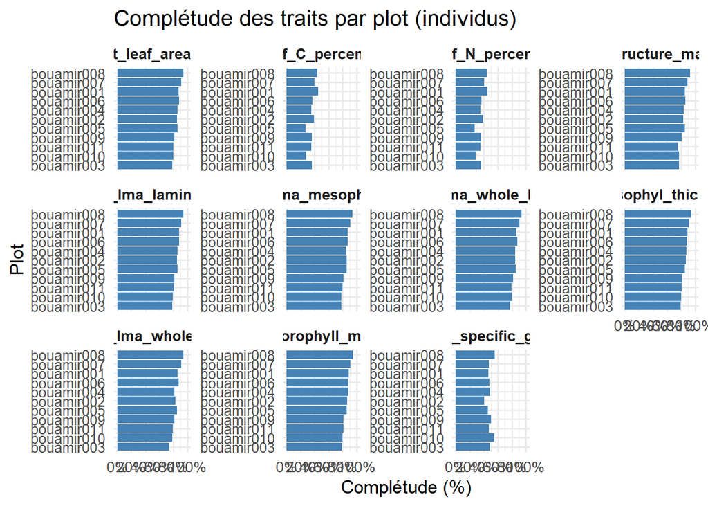

```r
tree_ind_dataset <-
  tree_data %>%
  left_join(meta_data %>% select(plot_name, locality_name),
            by = c("plot_name" = "plot_name")) %>%
  ### keep only bouamir plots
  filter(!grepl("_observatory", plot_name),
         grepl("bouamir", plot_name)) %>%
  select(tax_sp_level, plot_name)


joined_plot_traits <-
  tree_ind_dataset %>%
  left_join(traits_taxa %>%
  select(
    tax_sp_level,
    t_lma_lamina,
    t_lma_mesophyll,
    t_lma_whole_leaf,
    t_mesophyl_thickness,
    t_SPAD_chlorophyll_measurement,
    t_leaf_area,
    t_leaf_structure_mass_area,
    t_twig_specific_gravity,
    t_leaf_N_percentage,
    t_leaf_C_percentage,
    t_ratio_lma_whole_meso
  )) %>%
  arrange(tax_sp_level)
trait_cols <- grep("^t_", names(joined_plot_traits), value = TRUE)

prop_indiv_plot <-
  joined_plot_traits %>%
  group_by(plot_name) %>%
  summarise(across(all_of(trait_cols),
                   ~ round(mean(!is.na(.x)) * 100, 1),
                   .names = "prop_indiv_{.col}"))

prop_species_plot <-
  joined_plot_traits %>%
  group_by(plot_name, tax_sp_level) %>%
  summarise(across(all_of(trait_cols), ~ any(!is.na(.x))), .groups = "drop") %>%
  group_by(plot_name) %>%
  summarise(across(all_of(trait_cols),
                   ~ round(mean(.x) * 100, 1),
                   .names = "prop_species_{.col}"))

prop_indiv_plot_long <- prop_indiv_plot %>%
  pivot_longer(
    cols = starts_with("prop_indiv_"),
    names_to = "trait",
    values_to = "prop"
  ) %>%
  mutate(trait = sub("^prop_indiv_", "", trait))

ggplot(prop_indiv_plot_long, aes(
  x = reorder(plot_name, prop),
  y = prop # conversion en pourcentage
)) +
  geom_col(fill = "steelblue") +
  facet_wrap(~ trait, scales = "free_y") +
  coord_flip() +
  scale_y_continuous(
    limits = c(0, 100),
    breaks = seq(0, 100, by = 20),
    labels = function(x) paste0(x, "%")
  ) +
  labs(
    x = "Plot",
    y = "Complétude (%)",
    title = "Complétude des traits par plot (individus)"
  ) +
  theme_minimal(base_size = 13) +
  theme(
    strip.text = element_text(face = "bold"),
    axis.text.y = element_text(size = 10)
  )
```

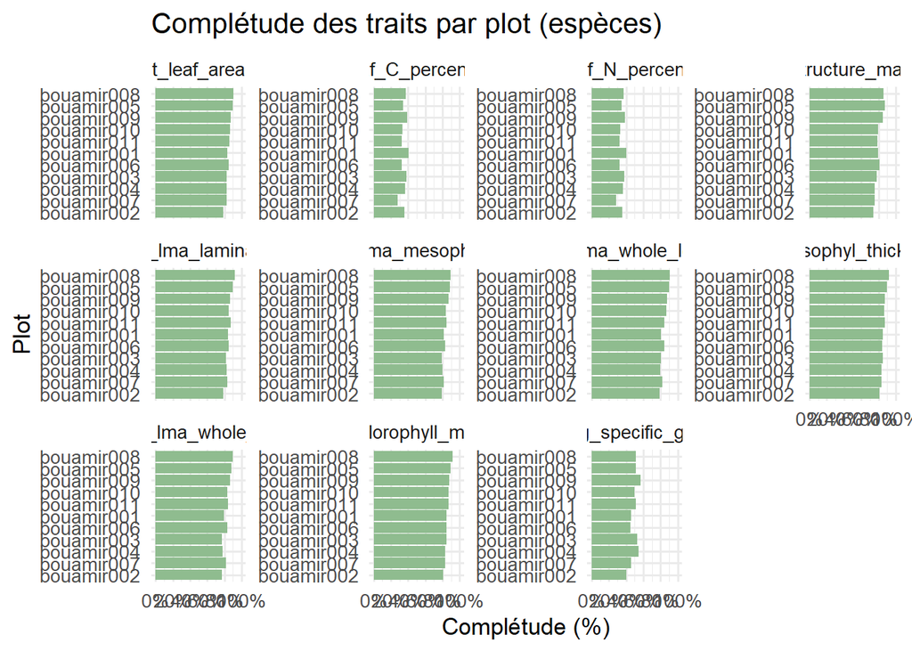

```r
prop_species_plot_long <- prop_species_plot %>%
  pivot_longer(
    cols = starts_with("prop_species_"),
    names_to = "trait",
    values_to = "prop"
  ) %>%
  mutate(trait = sub("^prop_species_", "", trait))

ggplot(prop_species_plot_long, aes(
  x = reorder(plot_name, prop),
  y = prop
)) +
  geom_col(fill = "darkseagreen") +
  facet_wrap(~ trait, scales = "free_y") +
  coord_flip() +
  scale_y_continuous(
    limits = c(0, 100),
    breaks = seq(0, 100, by = 20),
    labels = function(x) paste0(x, "%")
  ) +
  labs(
    x = "Plot",
    y = "Complétude (%)",
    title = "Complétude des traits par plot (espèces)"
  ) +
  theme_minimal(base_size = 13)
```

# Variance decomposition

Following the method in [Boisseaux et al 2024](https://besjournals.onlinelibrary.wiley.com/doi/full/10.1111/1365-2435.14679).

Results below are not comparable across traits because datasets varies. For example chlorophyll content and delta carbon measurements were measured on samples that favours within-species variation.

```r
MyData_Sp <-
  colnbr_per_sp %>%
  left_join(
    tree_data %>% select(
      id_n,
      taxa_bioclimatic_group,
      taxa_phenology,
      taxa_succession_guild
    ),
    by = c("id_data_individuals" = "id_n")
  ) %>%
  mutate(site = case_when(
   grepl("Mbalmayo", locality_name) ~ "Mbalmayo",
   grepl("Bouamir", locality_name) ~ "Bouamir"
  )) %>%
  ungroup()


### function for variance decomposition for each trait


func_var_components <- function(my_data,
                                col_tax = "tax_sp_level",
                                col_trait,
                                col_fixed_group) {
  my_data <-
    my_data %>%
    rename(
      taxa = all_of(col_tax),
      col_trait = all_of(col_trait),
      col_fixed_group = all_of(col_fixed_group)
    ) %>%
    select(taxa, col_trait, col_fixed_group) %>%
    filter(!is.na(taxa), !is.na(col_trait), !is.na(col_fixed_group))


  # Fit the linear mixed-effects model
  model <- nlme::lme(
    col_trait ~ col_fixed_group,
    random =  ~ 1 |
      taxa,
    data = my_data,
    na.action = na.omit,
    method = "ML"
  )

  Var_components <- lme4::VarCorr(model)
  var_sp <- as.numeric(Var_components[1, 1]) #for the random effects - species
  var_indv <- as.numeric(Var_components[2, 1]) #model residual, also known as the intraspecific residual


  #Fit the associated null model with random intercept on species
  null_model <- nlme::lme(
    col_trait ~ 1,
    random =  ~ 1 |
      taxa,
    data = my_data,
    na.action = na.omit,
    method = "ML"
  )

  # Obtain the variance of the random effect in the null model.
  random_variance_null <- as.numeric(lme4::VarCorr(null_model)[1, 1])

  # Obtain the residual variance
  residual_variance_null <- as.numeric(lme4::VarCorr(null_model)[2, 1])

  # Obtain the total variance of the null model
  v_0 <- random_variance_null + residual_variance_null

  # Calculate the variance component linked to the env't by substracting the residual variance of the model (var_indv) and the variance explained by the random factor, the species (var_sp), from the variance of the null model

  # Variance partitioning
  comp_sp <- round(100 * var_sp / v_0, 1)
  comp_indv <- round(100 * var_indv / v_0, 1)

  comp_envt <- 100 - (comp_indv +  comp_sp)

  res <- tibble(
    trait = col_trait,
    fixed_group = col_fixed_group,
    comp_var = c("species", "within_species", "group"),
    value = c(comp_sp, comp_indv, comp_envt)
  )

  return(res)
}

all_traits_names <-
  names(MyData_Sp %>% select(starts_with("t_")))

MyData_Sp <-
  MyData_Sp %>%
  mutate(t_leaf_delta_carbon_13 = abs(t_leaf_delta_carbon_13)) %>%
  mutate(across(starts_with("t_"), ~ log10(.x))) ## log transformation
```

Using phenology as a fixed group.

```r
res_list <- vector('list', length(all_traits_names))
for (i in 1:length(all_traits_names)) {
  res_list[[i]] <-
  func_var_components(my_data = MyData_Sp,
                 col_trait = all_traits_names[i],
                 col_fixed_group = "taxa_phenology")
}


res <- bind_rows(res_list)
res %>%
  filter(comp_var == "group")
```

```
## # A tibble: 13 × 4
##    trait                          fixed_group    comp_var   value
##    <chr>                          <chr>          <chr>      <dbl>
##  1 t_SPAD_chlorophyll_measurement taxa_phenology group     2.80
##  2 t_mesophyl_thickness           taxa_phenology group     0.300
##  3 t_lma_mesophyll                taxa_phenology group     2.90
##  4 t_lma_lamina                   taxa_phenology group     3.20
##  5 t_whole_leaf_area              taxa_phenology group     1.90
##  6 t_lma_whole_leaf               taxa_phenology group     4.90
##  7 t_leaf_area                    taxa_phenology group     4.30
##  8 t_leaf_structure_mass_area     taxa_phenology group     1.30
##  9 t_twig_specific_gravity        taxa_phenology group     0.1000
## 10 t_total_chlorophyll_content    taxa_phenology group     2.80
## 11 t_leaf_C_percentage            taxa_phenology group     0.400
## 12 t_leaf_delta_carbon_13         taxa_phenology group    11.2
## 13 t_leaf_N_percentage            taxa_phenology group     4.80
```

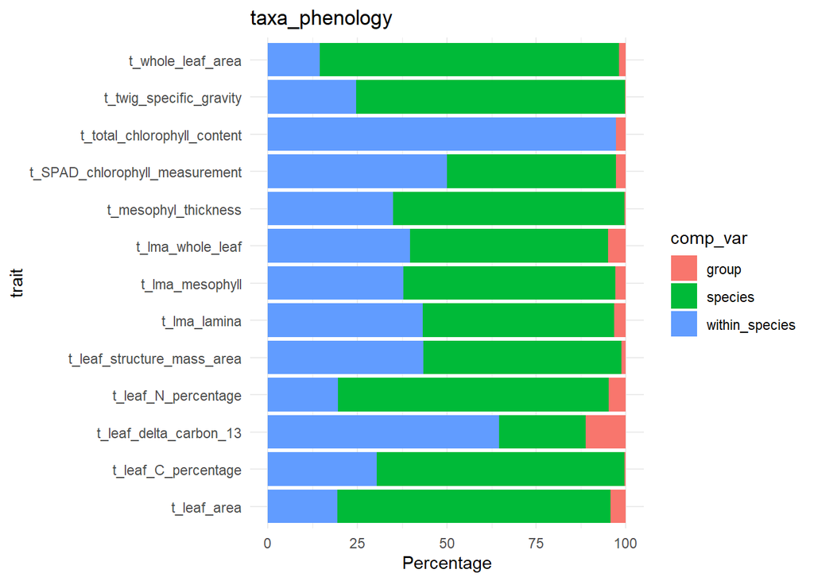

```r
ggplot(res, aes(x = trait, y = value, fill = comp_var)) +
  geom_bar(stat = "identity", position = "stack") +
  labs(title = "taxa_phenology", y = "Percentage") +
  theme_minimal() +
  coord_flip()
```

```r
# dataset_variance <- colnbr_per_sp %>%
#   left_join(taxa_level) %>%
#   filter(!is.na(tax_sp_level))
#
# dataset_variance_analysed <-
#   dataset_variance %>%
#   filter(!is.na(taxa_level_phenology)) %>%
#   select(-t_whole_leaf_area,
#          -t_leaf_structure_mass_area,
#          -t_leaf_N_percentage,
#          -t_leaf_C_percentage,
#          -t_leaf_delta_carbon_13,
#          -t_total_chlorophyll_content,
#          -t_twig_specific_gravity) %>%
#   mutate(lma = ifelse(is.na(t_lma_lamina), t_lma_mesophyll, t_lma_lamina)) %>% ## taking lma mesophyll if no lma lamina available
#   mutate(lma = ifelse(is.na(lma), t_lma_whole_leaf, lma)) %>% ## taking lma whole leaf if no lma mesophyll available
#   select(-starts_with("t_lma")) %>%
#   rename(t_lma = lma) %>%
#   ungroup() %>%
#   rowwise() %>%
#   filter(!any(is.na(c_across(where( ### keeping only species where all traits are available
#     is.numeric
#   )))))
#
# all_traits_names <-
#   names(dataset_variance_analysed %>% select(starts_with("t_")))
#
# res_list <- vector('list', length(all_traits_names))
# for (i in 1:length(all_traits_names)) {
#   res_list[[i]] <-
#     func_var_components(my_data = dataset_variance_analysed,
#                         col_trait = all_traits_names[i],
#                         col_fixed_group = "taxa_level_phenology")
# }
#
#
# res <- bind_rows(res_list)
# res %>%
#   filter(comp_var == "group")
#
# ggplot(res, aes(x = trait, y = value, fill = comp_var)) +
#   geom_bar(stat = "identity", position = "stack") +
#   labs(title = "taxa_level_phenology", y = "Percentage") +
#   theme_minimal() +
#   coord_flip()
```

Using guild as a fixed group.

```r
res_list <- vector('list', length(all_traits_names))
for (i in 1:length(all_traits_names)) {
  res_list[[i]] <-
  func_var_components(my_data = MyData_Sp,
                 col_trait = all_traits_names[i],
                 col_fixed_group = "taxa_succession_guild")
}


res <- bind_rows(res_list)
res %>%
  filter(comp_var == "group")
```

```
## # A tibble: 13 × 4
##    trait                          fixed_group           comp_var  value
##    <chr>                          <chr>                 <chr>     <dbl>
##  1 t_SPAD_chlorophyll_measurement taxa_succession_guild group     2.80
##  2 t_mesophyl_thickness           taxa_succession_guild group     0.300
##  3 t_lma_mesophyll                taxa_succession_guild group     3.20
##  4 t_lma_lamina                   taxa_succession_guild group     2
##  5 t_whole_leaf_area              taxa_succession_guild group     2.90
##  6 t_lma_whole_leaf               taxa_succession_guild group     5.30
##  7 t_leaf_area                    taxa_succession_guild group     4.8
##  8 t_leaf_structure_mass_area     taxa_succession_guild group     5.70
##  9 t_twig_specific_gravity        taxa_succession_guild group     3.80
## 10 t_total_chlorophyll_content    taxa_succession_guild group    19.2
## 11 t_leaf_C_percentage            taxa_succession_guild group     0
## 12 t_leaf_delta_carbon_13         taxa_succession_guild group     6.70
## 13 t_leaf_N_percentage            taxa_succession_guild group     1
```

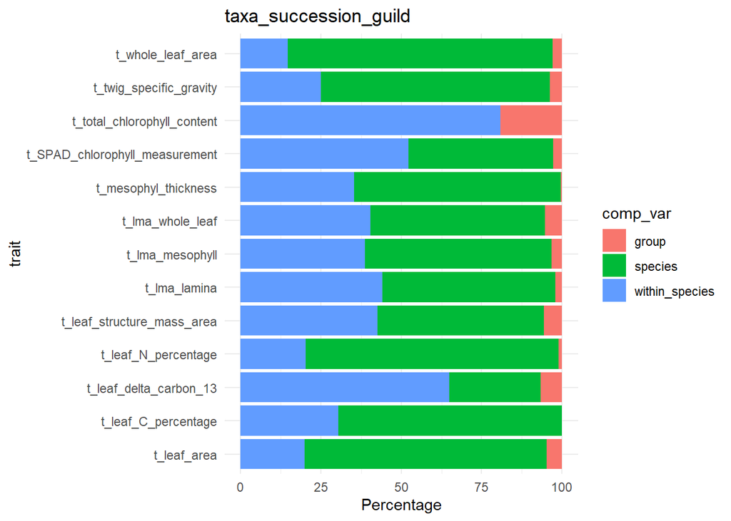

```r
ggplot(res, aes(x = trait, y = value, fill = comp_var)) +
  geom_bar(stat = "identity", position = "stack") +
  labs(title = "taxa_succession_guild", y = "Percentage") +
  theme_minimal() +
  coord_flip()
```